# Explicabilidad del Modelo

En este notebook, nos sumergimos en un análisis detallado de la explicabilidad de nuestro modelo XGBoost, destacando tanto sus aspectos globales como locales. La comprensión detallada de cómo el modelo toma decisiones es esencial, especialmente en el contexto crítico de clasificación de transacciones financieras fraudulentas.

### Librerias

```python
import pandas as pd
import numpy as np
import seaborn as sns
import matplotlib.pyplot as plt
import plotly.express as px
from imblearn.under_sampling import RandomUnderSampler
from collections import Counter
from sklearn import metrics
from sklearn.ensemble import AdaBoostClassifier, ExtraTreesClassifier, GradientBoostingClassifier, RandomForestClassifier
from sklearn.tree import DecisionTreeClassifier
from sklearn.feature_selection import VarianceThreshold, chi2, SelectFromModel
from sklearn.inspection import PartialDependenceDisplay
from sklearn.linear_model import Lasso, LogisticRegression
from sklearn.metrics import (ConfusionMatrixDisplay, auc, accuracy_score, classification_report, confusion_matrix,
                             f1_score, fbeta_score, make_scorer, precision_recall_curve, precision_score,
                             recall_score, roc_auc_score, roc_curve, silhouette_score)
from sklearn.model_selection import RandomizedSearchCV, cross_val_score, train_test_split
from sklearn.pipeline import Pipeline
from sklearn.svm import SVC
from xgboost import XGBClassifier
from lightgbm import LGBMClassifier
import pickle
import shap
shap.initjs()
import lime
from lime import lime_tabular
from sklearn.pipeline import make_pipeline
import warnings
warnings.filterwarnings("ignore")
```

### Division de los datos en train, test y validacion

```python
X = pd.read_csv("../data/X.csv")
y = pd.read_csv("../data/y.csv")
```

```python
X.head()
```

|  | income | name_email_similarity | prev_address_months_count | current_address_months_count | customer_age | days_since_request | intended_balcon_amount | zip_count_4w | velocity_6h | velocity_24h | ... | housing_status_BE | housing_status_BF | housing_status_BG | source_INTERNET | source_TELEAPP | device_os_linux | device_os_macintosh | device_os_other | device_os_windows | device_os_x11 |
| --- | --- | --- | --- | --- | --- | --- | --- | --- | --- | --- | --- | --- | --- | --- | --- | --- | --- | --- | --- | --- | --- |
| 0 | 0.9 | 0.166828 | 60.719967 | 88.0 | 50 | 0.020925 | 36.582496 | 769 | 10650.765523 | 3134.319630 | ... | 0 | 0 | 0 | 1 | 0 | 0 | 0 | 0 | 1 | 0 |
| 1 | 0.9 | 0.296286 | 60.719967 | 144.0 | 50 | 0.005418 | 36.582496 | 366 | 534.047319 | 2670.918292 | ... | 0 | 0 | 0 | 1 | 0 | 0 | 0 | 0 | 1 | 0 |
| 2 | 0.9 | 0.044985 | 60.719967 | 132.0 | 40 | 3.108549 | 36.582496 | 870 | 4048.534263 | 2893.621498 | ... | 0 | 0 | 0 | 1 | 0 | 0 | 0 | 1 | 0 | 0 |
| 3 | 0.9 | 0.159511 | 60.719967 | 22.0 | 50 | 0.019079 | 36.582496 | 810 | 3457.064063 | 4054.908412 | ... | 0 | 0 | 0 | 1 | 0 | 1 | 0 | 0 | 0 | 0 |
| 4 | 0.9 | 0.596414 | 60.719967 | 218.0 | 50 | 0.004441 | 36.582496 | 890 | 5020.341679 | 2728.237159 | ... | 0 | 0 | 0 | 1 | 0 | 0 | 1 | 0 | 0 | 0 |

5 rows × 51 columns

```python
y.head()
```

|  | fraud_bool |
| --- | --- |
| 0 | 1 |
| 1 | 1 |
| 2 | 1 |
| 3 | 1 |
| 4 | 1 |

```python
# Separo en train_0 y test
X_train_0, X_test, y_train_0, y_test = train_test_split(X, y, test_size=0.2, random_state=12)
```

```python
# Separo en train_1 y val
X_train_1, X_val, y_train_1, y_val = train_test_split(X_train_0, y_train_0, test_size=0.2, random_state=12)

print('Proporción de clases en y_train:', Counter(y_train_1))
```

```
Proporción de clases en y_train: Counter({'fraud_bool': 1})
```

### Undersampling de la muestra

```python
# Crear el objeto RandomUnderSampler con la proporción deseada, en este caso la de 0.1, es decir, 10% de la clase minoritaria
under_sampler = RandomUnderSampler(sampling_strategy=0.1, random_state=12)

# Aplicar el método de remuestreo
X_train_1, y_train_1 = under_sampler.fit_resample(X_train_1, y_train_1)

# Verificar la proporción después del undersampling
print('Undersampled dataset shape %s' % Counter(y_train_1))
```

```
Undersampled dataset shape Counter({'fraud_bool': 1})
```

Aplicamos un undersampling, en este caso la de 0.1, es decir, 10% de la clase minoritaria.

Esto quiere decir que haya una proporción de 90% no fraude y un 10% de fraude en el Train_1 que utilizaremos para los modelos en bruto y que compararemos con la validación.

```python
# Aplicar undersampling a tus datos
X_train_2, y_train_2 = under_sampler.fit_resample(X_train_0, y_train_0)

# Verificar la proporción después del undersampling
print('Undersampled dataset shape %s' % Counter(y_train_2))
```

```
Undersampled dataset shape Counter({'fraud_bool': 1})
```

Aplicamos un undersampling, en este caso la de 0.1, es decir, 10% de la clase minoritaria.

Esto quiere decir que haya una proporción de 90% no fraude y un 10% de fraude en el Train_2 que utilizaremos para los modelos con hiperparametros y que compararemos con el test.

## Explicabilidad General

### Explicabilidad General con SHAP

```python
# Cargo el modelo XGB de los mejores hiperparámetros obtenidos en el notebook de hiperparámetros
modelo = pickle.load(open('../models/modelo_XGB_best_estim.pkl', 'rb'))
```

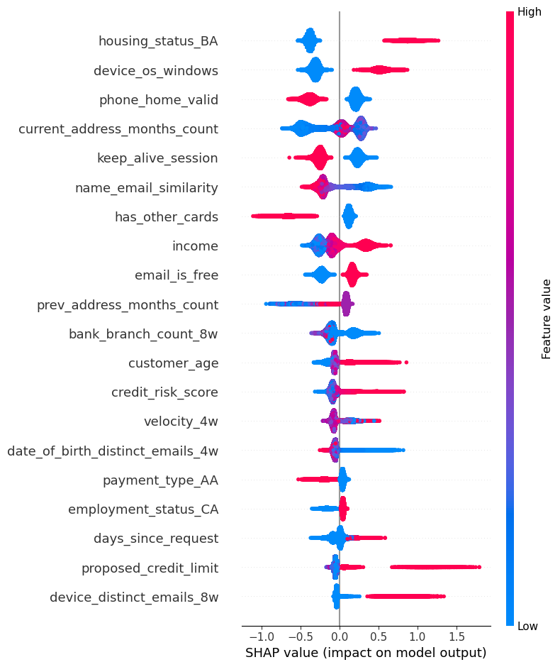

```python
# Definimo explainer para SHAP
explainer = shap.TreeExplainer(modelo.named_steps['classifier'])
# Calculo los valores de SHAP
shap_values = explainer.shap_values(X_test)
# Grafico
shap.summary_plot(shap_values, X_test)
```

El gráfico SHAP es una herramienta valiosa para identificar las variables clave que influyen en las predicciones del modelo y entender sus contribuciones específicas. Al observar este gráfico, destacamos varios patrones interesantes:

-Variables con Línea Roja a la Derecha y Azul a la Izquierda: significa que los valores altos de estas variables contribuyen positivamente, mientras que los bajos contribuyen negativamente a las predicciones del modelo. Ejemplos notables incluyen 'housing_status_BA' y 'device_os_windows'.

-Variables con Línea Roja a la Izquierda y Azul a la Derecha: significa que los valores bajos de estas variables contribuyen positivamente, mientras que los altos contribuyen negativamente a las predicciones. Ejemplos notables son 'phone_home_valid', 'keep_alive_session' y 'has_other_cards'.

En resumen, en este gráfico, la posición hacia la derecha indica mayor impacto. Las variables con líneas tanto rojas como azules hacia la derecha tienen una influencia más fuerte en las predicciones.

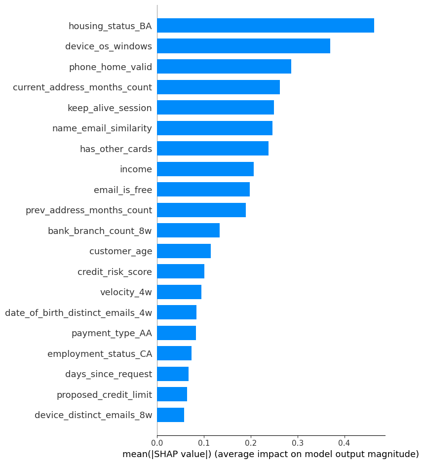

```python
# Grafico de importancia de variables con SHAP
shap.summary_plot(shap_values, X_test, plot_type="bar")
```

Este gráfico de barras es una variante de la visualización SHAP, y destaca la importancia relativa de cada variable. Las barras más grandes indican las variables más influyentes en las predicciones del modelo.

Utilizando la biblioteca SHAP, desglosamos globalmente las contribuciones de cada característica en las predicciones del modelo. Después de cargar nuestro modelo XGBoost y definir un explainer específico para SHAP, calculamos los valores de SHAP y generamos visualizaciones significativas. El gráfico SHAP summary nos ofrece una visión clara de la influencia de diferentes variables en las predicciones del modelo. Al observar patrones interesantes, destacamos la importancia de variables como 'housing_status_BA', 'device_os_windows', 'phone_home_valid' y otras, proporcionando una visión detallada de su impacto.

El gráfico de barras de importancia de variables con SHAP complementa esta visualización, ofreciendo una representación rápida de las variables más influyentes en las predicciones del modelo.

### Explicabilidad con Sklearn: Selección de Variables Importantes

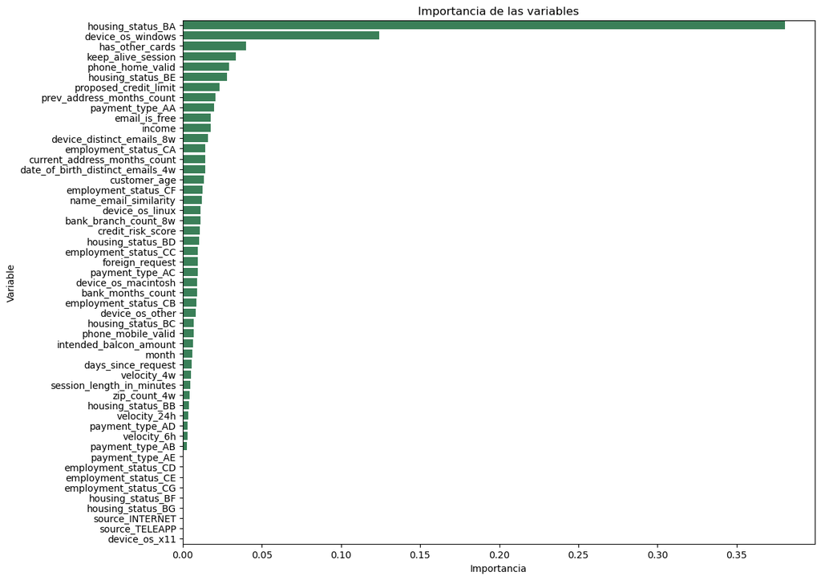

```python
# Selecciono las variables más importantes
xgb_model = modelo.named_steps['classifier']
important_variables = xgb_model.feature_importances_
# Creo un dataframe con las variables y su importancia
feature_names = X_test.columns
# Ordeno las variables por importancia
importancia_variables = sorted(zip(feature_names, important_variables), key=lambda tup: tup[1], reverse=True)
# Creo un dataframe con las variables y su importancia
importancia_variables_df = pd.DataFrame(importancia_variables, columns=['Variable', 'Importancia'])
# Grafico las variables por importancia
plt.figure(figsize=(12, 10))
sns.barplot(x='Importancia', y='Variable', data=importancia_variables_df, color='seagreen')
plt.title('Importancia de las variables')
plt.show()
```

Además, realizamos una exploración exhaustiva de la importancia de las variables utilizando Sklearn. Este enfoque nos permite identificar y seleccionar las variables más críticas para las predicciones del modelo XGBoost. Mediante el acceso al modelo subyacente, extraemos la importancia de cada variable y creamos un dataframe que resume estos hallazgos.

En el proceso de selección de variables importantes, se destaca claramente que 'housing_status_BA' y 'device_os_windows' emergen como las variables más influyentes. Estas dos características, en particular, sobresalen por su significativo impacto en las predicciones del modelo, fortaleciendo la coherencia de los resultados obtenidos previamente mediante SHAP.

Es notable destacar la convergencia entre los resultados de este análisis con Sklearn y el anterior con SHAP. La prominencia de 'housing_status_BA' y 'device_os_windows' en ambos enfoques refuerza su importancia y validez en el contexto de las predicciones del modelo XGBoost. Esta consistencia entre métodos distintos de evaluación subraya la robustez y la confiabilidad de estos atributos como impulsores fundamentales de las decisiones del modelo.

Este análisis conjunto de SHAP y Sklearn proporciona una visión integral de la explicabilidad de nuestro modelo XGBoost, sentando las bases para una comprensión rigurosa y detallada de sus decisiones a nivel global y local. Estas revelaciones no solo fortalecen la confianza en las predicciones del modelo, sino que también ofrecen una base sólida para futuras optimizaciones y mejoras.

## Explicabilidad Local

### Explicabilidad Local con LIME

```python
# Crea un objeto explainer LIME
explainer = lime_tabular.LimeTabularExplainer(X_test.values, feature_names=X_test.columns, class_names=['No Fraud', 'Fraud'], discretize_continuous=False)

# Elige una instancia específica para explicar (por ejemplo, la primera)
instance_to_explain = X_test.iloc[0, :]

# Explicación LIME para la instancia seleccionada
lime_explanation = explainer.explain_instance(instance_to_explain, xgb_model.predict_proba)

# Mostrar la explicación LIME
lime_explanation.show_in_notebook()
```

[output not shown]

LIME ayuda a entender cómo el modelo toma decisiones para casos individuales, desglosando la contribución de cada característica en la predicción.

Luego, encontramos una línea de variables: aquellas a la derecha de la línea central pueden estar asociadas a una mayor probabilidad de 'Fraude', mientras que las de la izquierda pueden estar más asociadas a 'No Fraude'.

```python
xgb_model=(modelo.named_steps['classifier'])
# Crea un objeto explainer LIME
explainer = lime_tabular.LimeTabularExplainer(X_test.values, feature_names=X_test.columns, class_names=['No Fraud', 'Fraud'], discretize_continuous=False)

# Elige una instancia específica para explicar (por ejemplo, la primera)
instance_to_explain = X_test.iloc[111, :]

# Explicación LIME para la instancia seleccionada
lime_explanation = explainer.explain_instance(instance_to_explain, xgb_model.predict_proba)

# Mostrar la explicación LIME
lime_explanation.show_in_notebook()
```

[output not shown]

En la línea de variables, se incorporan nuevas, como 'credit_risk_score', mientras que otras se mantienen consistentes.

La exploración de la explicabilidad no estaría completa sin un análisis detallado a nivel local utilizando LIME. Seleccionamos instancias específicas para desentrañar cómo diferentes variables impactan las predicciones del modelo para casos individuales.

A través de gráficos LIME, examinamos detalladamente la contribución de variables como 'prev_address_month_count', 'name_email_similarity' y 'device_os_windows' en las predicciones del modelo. Estudiamos cada variable y su efecto específico en la confianza del modelo al predecir 'No Fraude' o 'Fraude'.

Adicionalmente, exploramos cambios en la probabilidad de predicción y nuevas variables, como 'income', 'name_email_similarity', 'device_os_windows' y 'credit_risk_score', mediante un segundo gráfico LIME. Cada variable aporta a la confianza del modelo en su predicción específica, proporcionando una comprensión detallada de cómo las características influyen en las predicciones individuales.

Este enfoque integral, que abarca SHAP, Sklearn y LIME, nos suministra un entendimiento profundo de nuestro modelo XGBoost, tanto a nivel global como local. Estas revelaciones no solo refuerzan la confianza en las predicciones del modelo, sino que también ofrecen una visión detallada que sirve como guía valiosa para futuras optimizaciones y perfeccionamientos.

## Conclusión

Durante el desarrollo y la evaluación de modelos para la detección de fraudes, hemos llegado a una conclusión fundamental. Después de exhaustivos análisis y comparaciones, hemos elegido el modelo XGBoost (XGB) como nuestra opción principal, debido a sui gran desempeño, superando ligeramente a alternativas como LightGBM. Esta elección se basa en el equilibrio logrado entre la precisión en la detección de fraudes y la eficiencia computacional.

Al explorar la importancia de las variables mediante enfoques como Lasso, Gradient Boosting y Extra Tree Classifier, hemos confirmado de manera consistente que variables clave como 'housing_status_BA', 'phone_home_valid' y 'device_os_windows' son esenciales para explicar las predicciones de nuestro modelo. Estas observaciones han sido respaldadas mediante análisis más detallados utilizando técnicas como Shap, Lime y Sklearn.

El resultado obtenido no solo proporciona un modelo efectivo, sino también insights valiosos sobre las características que más influyen en la predicción de fraudes en nuestro conjunto de datos. Además, este proyecto representa un paso significativo hacia la comprensión y explicación transparente de las decisiones del modelo en el contexto del análisis de variables clave.